# Capstone Project: Create a Customer Segmentation Report for Arvato Financial Services

In this project, you will analyze demographics data for customers of a mail-order sales company in Germany, comparing it against demographics information for the general population. You'll use unsupervised learning techniques to perform customer segmentation, identifying the parts of the population that best describe the core customer base of the company. Then, you'll apply what you've learned on a third dataset with demographics information for targets of a marketing campaign for the company, and use a model to predict which individuals are most likely to convert into becoming customers for the company. The data that you will use has been provided by our partners at Bertelsmann Arvato Analytics, and represents a real-life data science task.

If you completed the first term of this program, you will be familiar with the first part of this project, from the unsupervised learning project. The versions of those two datasets used in this project will include many more features and has not been pre-cleaned. You are also free to choose whatever approach you'd like to analyzing the data rather than follow pre-determined steps. In your work on this project, make sure that you carefully document your steps and decisions, since your main deliverable for this project will be a blog post reporting your findings.

```python
# import libraries here; add more as necessary
import numpy as np
import pandas as pd
import matplotlib.pyplot as plt
import seaborn as sns
import missingno as msno
import emoji
import time

from sklearn.impute import SimpleImputer
from sklearn.preprocessing import StandardScaler
from sklearn.decomposition import PCA

# magic word for producing visualizations in notebook
%matplotlib inline

sns.set(style="whitegrid")
pd.set_option('display.max_rows', 500)
pd.set_option('display.max_columns', 500)
pd.set_option('display.width', 1000)
```

```python
# !pip install missingno
# import missingno as msno
```

## Load Necessary Data

```python
# to drop unnamed columns
def drop_unnamed_cols(cols):
    return cols[cols.str.contains("Unnamed")]


def get_data_information():

    # reading data dictionary
    data_dict = pd.read_excel("DIAS Information Levels - Attributes 2017.xlsx",skiprows=1)
    data_dict = data_dict.drop(columns= drop_unnamed_cols(data_dict.columns))
    data_dict.loc[:,"Information level"] = data_dict["Information level"].fillna(method="ffill").fillna(method="bfill").values

    # getting categorical levels info
    data_cat_lavels = pd.read_excel("DIAS Attributes - Values 2017.xlsx",skiprows=1)
    data_cat_lavels = data_cat_lavels.drop(columns= drop_unnamed_cols(data_cat_lavels.columns))
    data_cat_lavels = data_cat_lavels.fillna(method="ffill").fillna(method="bfill")

    return data_dict, data_cat_lavels


imputer = SimpleImputer(strategy="most_frequent")
std_scalar = StandardScaler()
```

```python
# load in the data
# azdias = pd.read_csv('data/Udacity_AZDIAS_052018.csv', sep=';')
# customers = pd.read_csv('data/Udacity_CUSTOMERS_052018.csv', sep=';')
```

oops.... Got warning for [18,19] columns

# Let's Understand the Data

```python
azdias.head()
```

|  | LNR | AGER_TYP | AKT_DAT_KL | ALTER_HH | ALTER_KIND1 | ALTER_KIND2 | ALTER_KIND3 | ALTER_KIND4 | ALTERSKATEGORIE_FEIN | ANZ_HAUSHALTE_AKTIV | ANZ_HH_TITEL | ANZ_KINDER | ANZ_PERSONEN | ANZ_STATISTISCHE_HAUSHALTE | ANZ_TITEL | ARBEIT | BALLRAUM | CAMEO_DEU_2015 | CAMEO_DEUG_2015 | CAMEO_INTL_2015 | CJT_GESAMTTYP | CJT_KATALOGNUTZER | CJT_TYP_1 | CJT_TYP_2 | CJT_TYP_3 | CJT_TYP_4 | CJT_TYP_5 | CJT_TYP_6 | D19_BANKEN_ANZ_12 | … |
| --- | --- | --- | --- | --- | --- | --- | --- | --- | --- | --- | --- | --- | --- | --- | --- | --- | --- | --- | --- | --- | --- | --- | --- | --- | --- | --- | --- | --- | --- | --- |
| 0 | 910215 | -1 | NaN | NaN | NaN | NaN | NaN | NaN | NaN | NaN | NaN | NaN | NaN | NaN | NaN | NaN | NaN | NaN | NaN | NaN | 2.0 | 5.0 | 1.0 | 1.0 | 5.0 | 5.0 | 5.0 | 5.0 | 0 | … |
| 1 | 910220 | -1 | 9.0 | 0.0 | NaN | NaN | NaN | NaN | 21.0 | 11.0 | 0.0 | 0.0 | 2.0 | 12.0 | 0.0 | 3.0 | 6.0 | 8A | 8 | 51 | 5.0 | 1.0 | 5.0 | 5.0 | 2.0 | 3.0 | 1.0 | 1.0 | 0 | … |
| 2 | 910225 | -1 | 9.0 | 17.0 | NaN | NaN | NaN | NaN | 17.0 | 10.0 | 0.0 | 0.0 | 1.0 | 7.0 | 0.0 | 3.0 | 2.0 | 4C | 4 | 24 | 3.0 | 2.0 | 4.0 | 4.0 | 1.0 | 3.0 | 2.0 | 2.0 | 0 | … |
| 3 | 910226 | 2 | 1.0 | 13.0 | NaN | NaN | NaN | NaN | 13.0 | 1.0 | 0.0 | 0.0 | 0.0 | 2.0 | 0.0 | 2.0 | 4.0 | 2A | 2 | 12 | 2.0 | 3.0 | 2.0 | 2.0 | 4.0 | 4.0 | 5.0 | 3.0 | 0 | … |
| 4 | 910241 | -1 | 1.0 | 20.0 | NaN | NaN | NaN | NaN | 14.0 | 3.0 | 0.0 | 0.0 | 4.0 | 3.0 | 0.0 | 4.0 | 2.0 | 6B | 6 | 43 | 5.0 | 3.0 | 3.0 | 3.0 | 3.0 | 4.0 | 3.0 | 3.0 | 3 | … |

```python
customers.head()
```

|  | LNR | AGER_TYP | AKT_DAT_KL | ALTER_HH | ALTER_KIND1 | ALTER_KIND2 | ALTER_KIND3 | ALTER_KIND4 | ALTERSKATEGORIE_FEIN | ANZ_HAUSHALTE_AKTIV | ANZ_HH_TITEL | ANZ_KINDER | ANZ_PERSONEN | ANZ_STATISTISCHE_HAUSHALTE | ANZ_TITEL | ARBEIT | BALLRAUM | CAMEO_DEU_2015 | CAMEO_DEUG_2015 | CAMEO_INTL_2015 | CJT_GESAMTTYP | CJT_KATALOGNUTZER | CJT_TYP_1 | CJT_TYP_2 | CJT_TYP_3 | CJT_TYP_4 | CJT_TYP_5 | CJT_TYP_6 | D19_BANKEN_ANZ_12 | … |
| --- | --- | --- | --- | --- | --- | --- | --- | --- | --- | --- | --- | --- | --- | --- | --- | --- | --- | --- | --- | --- | --- | --- | --- | --- | --- | --- | --- | --- | --- | --- |
| 0 | 9626 | 2 | 1.0 | 10.0 | NaN | NaN | NaN | NaN | 10.0 | 1.0 | 0.0 | 0.0 | 2.0 | 1.0 | 0.0 | 1.0 | 3.0 | 1A | 1 | 13 | 5.0 | 4.0 | 1.0 | 1.0 | 5.0 | 5.0 | 5.0 | 5.0 | 0 | … |
| 1 | 9628 | -1 | 9.0 | 11.0 | NaN | NaN | NaN | NaN | NaN | NaN | NaN | 0.0 | 3.0 | NaN | 0.0 | NaN | NaN | NaN | NaN | NaN | NaN | NaN | NaN | NaN | NaN | NaN | NaN | NaN | 0 | … |
| 2 | 143872 | -1 | 1.0 | 6.0 | NaN | NaN | NaN | NaN | 0.0 | 1.0 | 0.0 | 0.0 | 1.0 | 1.0 | 0.0 | 3.0 | 7.0 | 5D | 5 | 34 | 2.0 | 5.0 | 2.0 | 2.0 | 5.0 | 5.0 | 5.0 | 5.0 | 0 | … |
| 3 | 143873 | 1 | 1.0 | 8.0 | NaN | NaN | NaN | NaN | 8.0 | 0.0 | NaN | 0.0 | 0.0 | 1.0 | 0.0 | 1.0 | 7.0 | 4C | 4 | 24 | 2.0 | 5.0 | 1.0 | 1.0 | 5.0 | 5.0 | 5.0 | 5.0 | 0 | … |
| 4 | 143874 | -1 | 1.0 | 20.0 | NaN | NaN | NaN | NaN | 14.0 | 7.0 | 0.0 | 0.0 | 4.0 | 7.0 | 0.0 | 3.0 | 3.0 | 7B | 7 | 41 | 6.0 | 4.0 | 3.0 | 3.0 | 3.0 | 4.0 | 3.0 | 3.0 | 1 | … |

```python
azdias.describe(include= "all")
```

|  | LNR | AGER_TYP | AKT_DAT_KL | ALTER_HH | ALTER_KIND1 | ALTER_KIND2 | ALTER_KIND3 | ALTER_KIND4 | ALTERSKATEGORIE_FEIN | ANZ_HAUSHALTE_AKTIV | ANZ_HH_TITEL | ANZ_KINDER | ANZ_PERSONEN | ANZ_STATISTISCHE_HAUSHALTE | ANZ_TITEL | ARBEIT | BALLRAUM | CAMEO_DEU_2015 | CAMEO_DEUG_2015 | CAMEO_INTL_2015 | CJT_GESAMTTYP | CJT_KATALOGNUTZER | CJT_TYP_1 | CJT_TYP_2 | CJT_TYP_3 | CJT_TYP_4 | CJT_TYP_5 | CJT_TYP_6 | D19_BANKEN_ANZ_12 | … |
| --- | --- | --- | --- | --- | --- | --- | --- | --- | --- | --- | --- | --- | --- | --- | --- | --- | --- | --- | --- | --- | --- | --- | --- | --- | --- | --- | --- | --- | --- | --- |
| count | 8.912210e+05 | 891221.000000 | 817722.000000 | 817722.000000 | 81058.000000 | 29499.000000 | 6170.000000 | 1205.000000 | 628274.000000 | 798073.000000 | 794213.000000 | 817722.000000 | 817722.000000 | 798073.000000 | 817722.000000 | 794005.000000 | 797481.000000 | 792242 | 792242 | 792242 | 886367.000000 | 886367.000000 | 886367.000000 | 886367.000000 | 886367.000000 | 886367.000000 | 886367.000000 | 886367.000000 | 891221.000000 | … |
| unique | NaN | NaN | NaN | NaN | NaN | NaN | NaN | NaN | NaN | NaN | NaN | NaN | NaN | NaN | NaN | NaN | NaN | 45 | 19 | 43 | NaN | NaN | NaN | NaN | NaN | NaN | NaN | NaN | NaN | … |
| top | NaN | NaN | NaN | NaN | NaN | NaN | NaN | NaN | NaN | NaN | NaN | NaN | NaN | NaN | NaN | NaN | NaN | 6B | 8 | 51 | NaN | NaN | NaN | NaN | NaN | NaN | NaN | NaN | NaN | … |
| freq | NaN | NaN | NaN | NaN | NaN | NaN | NaN | NaN | NaN | NaN | NaN | NaN | NaN | NaN | NaN | NaN | NaN | 56672 | 78023 | 77576 | NaN | NaN | NaN | NaN | NaN | NaN | NaN | NaN | NaN | … |
| mean | 6.372630e+05 | -0.358435 | 4.421928 | 10.864126 | 11.745392 | 13.402658 | 14.476013 | 15.089627 | 13.700717 | 8.287263 | 0.040647 | 0.154018 | 1.727637 | 7.599356 | 0.004162 | 3.167854 | 4.153043 | NaN | NaN | NaN | 3.632838 | 3.335264 | 3.368086 | 3.195014 | 3.351290 | 3.336151 | 3.360684 | 3.465980 | 0.122336 | … |
| std | 2.572735e+05 | 1.198724 | 3.638805 | 7.639683 | 4.097660 | 3.243300 | 2.712427 | 2.452932 | 5.079849 | 15.628087 | 0.324028 | 0.502389 | 1.155849 | 14.332201 | 0.068855 | 1.002376 | 2.183710 | NaN | NaN | NaN | 1.595021 | 1.493633 | 1.368331 | 1.401382 | 1.396508 | 1.373077 | 1.378992 | 1.328456 | 0.535950 | … |
| min | 1.916530e+05 | -1.000000 | 1.000000 | 0.000000 | 2.000000 | 2.000000 | 4.000000 | 7.000000 | 0.000000 | 0.000000 | 0.000000 | 0.000000 | 0.000000 | 0.000000 | 0.000000 | 1.000000 | 1.000000 | NaN | NaN | NaN | 1.000000 | 1.000000 | 1.000000 | 1.000000 | 1.000000 | 1.000000 | 1.000000 | 1.000000 | 0.000000 | … |
| 25% | 4.144580e+05 | -1.000000 | 1.000000 | 0.000000 | 8.000000 | 11.000000 | 13.000000 | 14.000000 | 11.000000 | 1.000000 | 0.000000 | 0.000000 | 1.000000 | 1.000000 | 0.000000 | 3.000000 | 2.000000 | NaN | NaN | NaN | 2.000000 | 2.000000 | 2.000000 | 2.000000 | 2.000000 | 2.000000 | 2.000000 | 2.000000 | 0.000000 | … |
| 50% | 6.372630e+05 | -1.000000 | 3.000000 | 13.000000 | 12.000000 | 14.000000 | 15.000000 | 15.000000 | 14.000000 | 4.000000 | 0.000000 | 0.000000 | 1.000000 | 3.000000 | 0.000000 | 3.000000 | 5.000000 | NaN | NaN | NaN | 4.000000 | 4.000000 | 3.000000 | 3.000000 | 3.000000 | 3.000000 | 3.000000 | 4.000000 | 0.000000 | … |
| 75% | 8.600680e+05 | -1.000000 | 9.000000 | 17.000000 | 15.000000 | 16.000000 | 17.000000 | 17.000000 | 17.000000 | 9.000000 | 0.000000 | 0.000000 | 2.000000 | 9.000000 | 0.000000 | 4.000000 | 6.000000 | NaN | NaN | NaN | 5.000000 | 5.000000 | 5.000000 | 5.000000 | 5.000000 | 5.000000 | 5.000000 | 5.000000 | 0.000000 | … |
| max | 1.082873e+06 | 3.000000 | 9.000000 | 21.000000 | 18.000000 | 18.000000 | 18.000000 | 18.000000 | 25.000000 | 595.000000 | 23.000000 | 11.000000 | 45.000000 | 449.000000 | 6.000000 | 9.000000 | 7.000000 | NaN | NaN | NaN | 6.000000 | 5.000000 | 5.000000 | 5.000000 | 5.000000 | 5.000000 | 5.000000 | 5.000000 | 6.000000 | … |

```python
customers.describe(include="all")
```

|  | LNR | AGER_TYP | AKT_DAT_KL | ALTER_HH | ALTER_KIND1 | ALTER_KIND2 | ALTER_KIND3 | ALTER_KIND4 | ALTERSKATEGORIE_FEIN | ANZ_HAUSHALTE_AKTIV | ANZ_HH_TITEL | ANZ_KINDER | ANZ_PERSONEN | ANZ_STATISTISCHE_HAUSHALTE | ANZ_TITEL | ARBEIT | BALLRAUM | CAMEO_DEU_2015 | CAMEO_DEUG_2015 | CAMEO_INTL_2015 | CJT_GESAMTTYP | CJT_KATALOGNUTZER | CJT_TYP_1 | CJT_TYP_2 | CJT_TYP_3 | CJT_TYP_4 | CJT_TYP_5 | CJT_TYP_6 | D19_BANKEN_ANZ_12 | … |
| --- | --- | --- | --- | --- | --- | --- | --- | --- | --- | --- | --- | --- | --- | --- | --- | --- | --- | --- | --- | --- | --- | --- | --- | --- | --- | --- | --- | --- | --- | --- |
| count | 191652.000000 | 191652.000000 | 145056.000000 | 145056.000000 | 11766.000000 | 5100.000000 | 1275.000000 | 236.000000 | 139810.000000 | 141725.000000 | 139542.000000 | 145056.000000 | 145056.000000 | 141725.000000 | 145056.000000 | 141176.000000 | 141693.000000 | 141224 | 141224 | 141224 | 188439.000000 | 188439.00000 | 188439.000000 | 188439.000000 | 188439.000000 | 188439.000000 | 188439.000000 | 188439.000000 | 191652.000000 | … |
| unique | NaN | NaN | NaN | NaN | NaN | NaN | NaN | NaN | NaN | NaN | NaN | NaN | NaN | NaN | NaN | NaN | NaN | 45 | 19 | 43 | NaN | NaN | NaN | NaN | NaN | NaN | NaN | NaN | NaN | … |
| top | NaN | NaN | NaN | NaN | NaN | NaN | NaN | NaN | NaN | NaN | NaN | NaN | NaN | NaN | NaN | NaN | NaN | 2D | 2 | 14 | NaN | NaN | NaN | NaN | NaN | NaN | NaN | NaN | NaN | … |
| freq | NaN | NaN | NaN | NaN | NaN | NaN | NaN | NaN | NaN | NaN | NaN | NaN | NaN | NaN | NaN | NaN | NaN | 11208 | 17574 | 14708 | NaN | NaN | NaN | NaN | NaN | NaN | NaN | NaN | NaN | … |
| mean | 95826.500000 | 0.344359 | 1.747525 | 11.352009 | 12.337243 | 13.672353 | 14.647059 | 15.377119 | 10.331579 | 4.965863 | 0.067413 | 0.136402 | 2.267828 | 4.701288 | 0.020392 | 2.824850 | 4.301758 | NaN | NaN | NaN | 3.677928 | 4.00994 | 2.665441 | 2.548490 | 4.516369 | 4.415317 | 4.519956 | 4.538838 | 0.091040 | … |
| std | 55325.311233 | 1.391672 | 1.966334 | 6.275026 | 4.006050 | 3.243335 | 2.753787 | 2.307653 | 4.134828 | 14.309694 | 0.545576 | 0.493249 | 1.390620 | 14.184081 | 0.152234 | 1.012415 | 2.114614 | NaN | NaN | NaN | 1.813975 | 1.37894 | 1.545714 | 1.557262 | 0.874722 | 1.025281 | 0.895371 | 0.886091 | 0.416684 | … |
| min | 1.000000 | -1.000000 | 1.000000 | 0.000000 | 2.000000 | 2.000000 | 5.000000 | 8.000000 | 0.000000 | 0.000000 | 0.000000 | 0.000000 | 0.000000 | 0.000000 | 0.000000 | 1.000000 | 1.000000 | NaN | NaN | NaN | 1.000000 | 1.00000 | 1.000000 | 1.000000 | 1.000000 | 1.000000 | 1.000000 | 1.000000 | 0.000000 | … |
| 25% | 47913.750000 | -1.000000 | 1.000000 | 8.000000 | 9.000000 | 11.000000 | 13.000000 | 14.000000 | 9.000000 | 1.000000 | 0.000000 | 0.000000 | 1.000000 | 1.000000 | 0.000000 | 2.000000 | 2.000000 | NaN | NaN | NaN | 2.000000 | 3.00000 | 1.000000 | 1.000000 | 4.000000 | 4.000000 | 4.000000 | 4.000000 | 0.000000 | … |
| 50% | 95826.500000 | 0.000000 | 1.000000 | 11.000000 | 13.000000 | 14.000000 | 15.000000 | 16.000000 | 10.000000 | 1.000000 | 0.000000 | 0.000000 | 2.000000 | 1.000000 | 0.000000 | 3.000000 | 5.000000 | NaN | NaN | NaN | 4.000000 | 5.00000 | 2.000000 | 2.000000 | 5.000000 | 5.000000 | 5.000000 | 5.000000 | 0.000000 | … |
| 75% | 143739.250000 | 2.000000 | 1.000000 | 16.000000 | 16.000000 | 16.000000 | 17.000000 | 17.000000 | 13.000000 | 4.000000 | 0.000000 | 0.000000 | 3.000000 | 3.000000 | 0.000000 | 4.000000 | 6.000000 | NaN | NaN | NaN | 6.000000 | 5.00000 | 4.000000 | 4.000000 | 5.000000 | 5.000000 | 5.000000 | 5.000000 | 0.000000 | … |
| max | 191652.000000 | 3.000000 | 9.000000 | 21.000000 | 18.000000 | 18.000000 | 18.000000 | 18.000000 | 25.000000 | 523.000000 | 23.000000 | 8.000000 | 21.000000 | 375.000000 | 5.000000 | 9.000000 | 7.000000 | NaN | NaN | NaN | 6.000000 | 5.00000 | 5.000000 | 5.000000 | 5.000000 | 5.000000 | 5.000000 | 5.000000 | 6.000000 | … |

```python
print(f" # of common columns in {len(set(azdias.columns) & set(customers.columns) )}")
print(f" # of columns not in customers but exist in global data {len(set(azdias.columns) - set(customers.columns) )}")
print(f" # of columns not in global data but exist in customers {len(set(customers.columns) -set(azdias.columns)  )}")
only_in_cust = set(customers.columns) -set(azdias.columns)
only_in_cust
```

```
 # of common columns in 366
 # of columns not in customers but exist in global data 0
 # of columns not in global data but exist in customers 3
```

```
{'CUSTOMER_GROUP', 'ONLINE_PURCHASE', 'PRODUCT_GROUP'}
```

```python
customers[only_in_cust]
```

|  | CUSTOMER_GROUP | ONLINE_PURCHASE | PRODUCT_GROUP |
| --- | --- | --- | --- |
| 0 | MULTI_BUYER | 0 | COSMETIC_AND_FOOD |
| 1 | SINGLE_BUYER | 0 | FOOD |
| 2 | MULTI_BUYER | 0 | COSMETIC_AND_FOOD |
| 3 | MULTI_BUYER | 0 | COSMETIC |
| 4 | MULTI_BUYER | 0 | FOOD |
| ... | ... | ... | ... |
| 191647 | MULTI_BUYER | 0 | COSMETIC_AND_FOOD |
| 191648 | SINGLE_BUYER | 0 | COSMETIC |
| 191649 | MULTI_BUYER | 0 | COSMETIC_AND_FOOD |
| 191650 | SINGLE_BUYER | 0 | FOOD |
| 191651 | MULTI_BUYER | 0 | COSMETIC_AND_FOOD |

191652 rows × 3 columns

We have a Data dictionary so let's use it and get the overall view of all the columns.

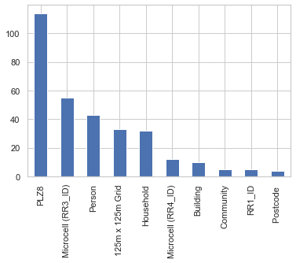

```python
data_dict["Information level"].value_counts().plot(kind="bar")
```

```python
data_dict[data_dict["Information level"] == "PLZ8"].head()
```

|  | Information level | Attribute | Description | Additional notes |
| --- | --- | --- | --- | --- |
| 194 | PLZ8 | KBA13_ALTERHALTER_30 | share of car owners below 31 within the PLZ8 | NaN |
| 195 | PLZ8 | KBA13_ALTERHALTER_45 | share of car owners between 31 and 45 within t... | NaN |
| 196 | PLZ8 | KBA13_ALTERHALTER_60 | share of car owners between 46 and 60 within t... | NaN |
| 197 | PLZ8 | KBA13_ALTERHALTER_61 | share of car owners elder than 60 within the PLZ8 | NaN |
| 198 | PLZ8 | KBA13_ANZAHL_PKW | number of cars in the PLZ8 | NaN |

PLZ8, is all about the cars and households levels and it has more attribute types than other information level , this might be very important level for us , let's see in the end 😎

# Missing Values

### Mixed data Type columns

Before we try to fix the missing values we need to take care of some columns which have different values than NaN or None and also we need to do something about warned columns.

```python
mixed_type_cols = azdias.columns[18:20].tolist()

# "CAMEO_INTL_2015" is renamed as CAMEO_DEUINTL_2015
data_dict = data_dict.replace("CAMEO_DEUINTL_2015","CAMEO_INTL_2015")
data_cat_lavels =data_cat_lavels.replace("CAMEO_DEUINTL_2015","CAMEO_INTL_2015")

mixed_type_cols
```

```
['CAMEO_DEUG_2015', 'CAMEO_INTL_2015']
```

```python
data_dict[data_dict.Attribute.isin(mixed_type_cols)]
```

|  | Information level | Attribute | Description | Additional notes |
| --- | --- | --- | --- | --- |
| 85 | Microcell (RR4_ID) | CAMEO_DEUG_2015 | CAMEO_4.0: uppergroup | New German CAMEO Typology established together... |
| 87 | Microcell (RR4_ID) | CAMEO_INTL_2015 | CAMEO_4.0: international classification | NaN |

```python
data_cat_lavels[data_cat_lavels.Attribute.isin(mixed_type_cols)]
```

|  | Attribute | Description | Value | Meaning |
| --- | --- | --- | --- | --- |
| 51 | CAMEO_DEUG_2015 | CAMEO classification 2015 - Uppergroup | -1 | unknown |
| 52 | CAMEO_DEUG_2015 | CAMEO classification 2015 - Uppergroup | 1 | upper class |
| 53 | CAMEO_DEUG_2015 | CAMEO classification 2015 - Uppergroup | 2 | upper middleclass |
| 54 | CAMEO_DEUG_2015 | CAMEO classification 2015 - Uppergroup | 3 | established middleclasse |
| 55 | CAMEO_DEUG_2015 | CAMEO classification 2015 - Uppergroup | 4 | consumption-oriented middleclass |
| 56 | CAMEO_DEUG_2015 | CAMEO classification 2015 - Uppergroup | 5 | active middleclass |
| 57 | CAMEO_DEUG_2015 | CAMEO classification 2015 - Uppergroup | 6 | low-consumption middleclass |
| 58 | CAMEO_DEUG_2015 | CAMEO classification 2015 - Uppergroup | 7 | lower middleclass |
| 59 | CAMEO_DEUG_2015 | CAMEO classification 2015 - Uppergroup | 8 | working class |
| 60 | CAMEO_DEUG_2015 | CAMEO classification 2015 - Uppergroup | 9 | urban working class |
| 105 | CAMEO_INTL_2015 | CAMEO classification 2015 - international typo... | -1 | unknown |
| 106 | CAMEO_INTL_2015 | (each German CAMEO code belongs to one interna... | 11 | Wealthy Households-Pre-Family Couples & Singles |
| 107 | CAMEO_INTL_2015 | (each German CAMEO code belongs to one interna... | 12 | Wealthy Households-Young Couples With Children |
| 108 | CAMEO_INTL_2015 | (each German CAMEO code belongs to one interna... | 13 | Wealthy Households-Families With School Age Ch... |
| 109 | CAMEO_INTL_2015 | (each German CAMEO code belongs to one interna... | 14 | Wealthy Households-Older Families & Mature Co... |
| 110 | CAMEO_INTL_2015 | (each German CAMEO code belongs to one interna... | 15 | Wealthy Households-Elders In Retirement |
| 111 | CAMEO_INTL_2015 | (each German CAMEO code belongs to one interna... | 21 | Prosperous Households-Pre-Family Couples & Sin... |
| 112 | CAMEO_INTL_2015 | (each German CAMEO code belongs to one interna... | 22 | Prosperous Households-Young Couples With Children |
| 113 | CAMEO_INTL_2015 | (each German CAMEO code belongs to one interna... | 23 | Prosperous Households-Families With School Age... |
| 114 | CAMEO_INTL_2015 | (each German CAMEO code belongs to one interna... | 24 | Prosperous Households-Older Families & Mature ... |
| 115 | CAMEO_INTL_2015 | (each German CAMEO code belongs to one interna... | 25 | Prosperous Households-Elders In Retirement |
| 116 | CAMEO_INTL_2015 | (each German CAMEO code belongs to one interna... | 31 | Comfortable Households-Pre-Family Couples & Si... |
| 117 | CAMEO_INTL_2015 | (each German CAMEO code belongs to one interna... | 32 | Comfortable Households-Young Couples With Chil... |
| 118 | CAMEO_INTL_2015 | (each German CAMEO code belongs to one interna... | 33 | Comfortable Households-Families With School Ag... |
| 119 | CAMEO_INTL_2015 | (each German CAMEO code belongs to one interna... | 34 | Comfortable Households-Older Families & Mature... |
| 120 | CAMEO_INTL_2015 | (each German CAMEO code belongs to one interna... | 35 | Comfortable Households-Elders In Retirement |
| 121 | CAMEO_INTL_2015 | (each German CAMEO code belongs to one interna... | 41 | Less Affluent Households-Pre-Family Couples & ... |
| 122 | CAMEO_INTL_2015 | (each German CAMEO code belongs to one interna... | 42 | Less Affluent Households-Young Couples With Ch... |
| 123 | CAMEO_INTL_2015 | (each German CAMEO code belongs to one interna... | 43 | Less Affluent Households-Families With School ... |
| 124 | CAMEO_INTL_2015 | (each German CAMEO code belongs to one interna... | 44 | Less Affluent Households-Older Families & Matu... |
| 125 | CAMEO_INTL_2015 | (each German CAMEO code belongs to one interna... | 45 | Less Affluent Households-Elders In Retirement |
| 126 | CAMEO_INTL_2015 | (each German CAMEO code belongs to one interna... | 51 | Poorer Households-Pre-Family Couples & Singles |
| 127 | CAMEO_INTL_2015 | (each German CAMEO code belongs to one interna... | 52 | Poorer Households-Young Couples With Children |
| 128 | CAMEO_INTL_2015 | (each German CAMEO code belongs to one interna... | 53 | Poorer Households-Families With School Age Chi... |
| 129 | CAMEO_INTL_2015 | (each German CAMEO code belongs to one interna... | 54 | Poorer Households-Older Families & Mature Couples |
| 130 | CAMEO_INTL_2015 | (each German CAMEO code belongs to one interna... | 55 | Poorer Households-Elders In Retirement |

```python
# converting to numeric , if mismatch value comes it will be automatically replace as np.nan

for col in mixed_type_cols:
    azdias[col] = pd.to_numeric(azdias[col],errors="coerce")
    customers[col] = pd.to_numeric(customers[col],errors="coerce")
```

### Unknown Values

Now we have no mixed data types in any columns , we have one more problem is an "unknown" values , which have different meaning but we can consider here as NaN values. But main proble is we have differnt values for unknown in every columns.

```python
unknown_attrs = data_cat_lavels[(data_cat_lavels.Meaning.str.contains("unknown"))]
unknown_attrs.loc[ :, "Value"] = unknown_attrs.Value.apply(lambda x : str(x).replace(" ","").split(",")).values
mapping_unknow_values = unknown_attrs.set_index("Attribute")["Value"].to_dict()
unknown_attrs.head()
```

|  | Attribute | Description | Value | Meaning |
| --- | --- | --- | --- | --- |
| 0 | AGER_TYP | best-ager typology | [-1] | unknown |
| 5 | ALTERSKATEGORIE_GROB | age classification through prename analysis | [-1, 0] | unknown |
| 11 | ALTER_HH | main age within the household | [0] | unknown / no main age detectable |
| 33 | ANREDE_KZ | gender | [-1, 0] | unknown |
| 40 | BALLRAUM | distance to next urban centre | [-1] | unknown |

```python
azdias_unk_cols = azdias.columns[azdias.columns.isin(mapping_unknow_values.keys())]
cust_unk_cols = customers.columns[customers.columns.isin(mapping_unknow_values.keys())]

for col in azdias_unk_cols:
    for replace_val in mapping_unknow_values[col]:
        azdias.loc[:,col] = azdias[col].replace(float(replace_val),np.nan)
        customers.loc[:,col] = customers[col].replace(float(replace_val),np.nan)

len(azdias_unk_cols),len(cust_unk_cols),len(mapping_unknow_values)
```

```
(226, 226, 233)
```

##### Great

Okay very well , Now we have all the unknow values converted to NaN, let's see the how many columns have very high missing values, and then we will apply specific imputation methods to specific types of problem 👍

#### Column wise missing values

```python
missing_prep_azdi = azdias.isnull().sum()/azdias.shape[0] * 100
missing_prep_azdi = missing_prep_azdi.sort_values(ascending=False).reset_index()
missing_prep_azdi.columns = ["attrs","missing_perce"]
```

```python
missing_prep_cust = customers.isnull().sum()/customers.shape[0] * 100
missing_prep_cust = missing_prep_cust.sort_values(ascending=False).reset_index()
missing_prep_cust.columns = ["attrs","missing_perce"]
```

[figure not shown]

```python
figsize = (10,80)
fig = plt.figure(figsize=figsize)

ax1 = fig.add_subplot(121)
sns.barplot(x="missing_perce",y="attrs",data=missing_prep_azdi,ax=ax1)

ax2 = fig.add_subplot(122)
sns.barplot(x="missing_perce",y="attrs",data=missing_prep_cust,ax=ax2)
```

##### conclusion

From above two plots we can say that almost all of the columns have < 40% missing values, except 6 columns.

Let's see how many columns have more than 15%, 20%, 25%, and 30% missing values

```python
for perce in [10,15,20,25,30]:
    more_than = missing_prep_azdi[missing_prep_azdi.missing_perce > perce].shape[0]
    more_than2 = missing_prep_cust[missing_prep_cust.missing_perce > perce].shape[0]

    print(f" there are {more_than} - {round(more_than*100/len(missing_prep_azdi),2)}% in global data and {more_than2} - {round(more_than2*100/len(missing_prep_cust),2)}% in customers cols more than {perce}% missing values.")
```

```
 there are 245 - 66.94% in global data and 259 - 70.19% in customers cols more than 10% missing values.
 there are 80 - 21.86% in global data and 259 - 70.19% in customers cols more than 15% missing values.
 there are 20 - 5.46% in global data and 259 - 70.19% in customers cols more than 20% missing values.
 there are 20 - 5.46% in global data and 236 - 63.96% in customers cols more than 25% missing values.
 there are 10 - 2.73% in global data and 12 - 3.25% in customers cols more than 30% missing values.
```

We can see here that if we consider dropping condition to more than 10% missing values than we will lost 67-70% of attributes , which is too much loss of the data. so we will consider 20% as our threshold to drop the missing values because in customers we also lose more values.

Let's see what are the columns have more than 20% missing values according to global data, which will be 20 columns from global and customers data

```python
more_than_20_cols =  missing_prep_azdi[missing_prep_azdi.missing_perce > 20]["attrs"].values
more_than_20_cols
```

```
array(['ALTER_KIND4', 'TITEL_KZ', 'ALTER_KIND3', 'ALTER_KIND2',
       'ALTER_KIND1', 'AGER_TYP', 'EXTSEL992', 'KK_KUNDENTYP',
       'KBA05_BAUMAX', 'ALTER_HH', 'ALTERSKATEGORIE_FEIN',
       'D19_KONSUMTYP', 'D19_LETZTER_KAUF_BRANCHE',
       'D19_VERSAND_ONLINE_QUOTE_12', 'D19_LOTTO',
       'D19_GESAMT_ONLINE_QUOTE_12', 'D19_TELKO_ONLINE_QUOTE_12',
       'D19_BANKEN_ONLINE_QUOTE_12', 'D19_SOZIALES',
       'D19_VERSI_ONLINE_QUOTE_12'], dtype=object)
```

```python
data_dict[data_dict.Attribute.isin(more_than_20_cols)]
```

|  | Information level | Attribute | Description | Additional notes |
| --- | --- | --- | --- | --- |
| 0 | Person | AGER_TYP | best-ager typology | in cooperation with Kantar TNS; the informatio... |
| 40 | Person | TITEL_KZ | flag whether this person holds an academic title | NaN |
| 43 | Household | ALTER_HH | main age within the household | NaN |
| 49 | Household | D19_KONSUMTYP | consumption type | NaN |
| 70 | Household | D19_GESAMT_ONLINE_QUOTE_12 | amount of online transactions within all trans... | NaN |
| 71 | Household | D19_BANKEN_ONLINE_QUOTE_12 | amount of online transactions within all trans... | NaN |
| 72 | Household | D19_VERSAND_ONLINE_QUOTE_12 | amount of online transactions within all trans... | NaN |
| 98 | Microcell (RR3_ID) | KBA05_BAUMAX | most common building-type within the cell | NaN |

```python
## let's remove all the columns which have more than 20% missing values in customers

azdias = azdias.drop(columns= more_than_20_cols)
customers = customers.drop(columns= more_than_20_cols)
```

#### Row wise Missing Values

```python
missing_prep_row_azdi = azdias.isnull().sum(axis=1)/azdias.shape[1] * 100
missing_prep_row_azdi = missing_prep_row_azdi.sort_values(ascending=False).reset_index()
missing_prep_row_azdi.columns = ["row_no","missing_perce"]
missing_prep_row_azdi.head()
```

|  | row_no | missing_perce |
| --- | --- | --- |
| 0 | 537799 | 72.131148 |
| 1 | 826869 | 72.131148 |
| 2 | 350182 | 71.857923 |
| 3 | 55664 | 71.857923 |
| 4 | 373501 | 71.857923 |

```python
missing_prep_row_cust = customers.isnull().sum(axis=1)/customers.shape[1] * 100
missing_prep_row_cust = missing_prep_row_cust.sort_values(ascending=False).reset_index()
missing_prep_row_cust.columns = ["row_no","missing_perce"]
missing_prep_row_cust.head()
```

|  | row_no | missing_perce |
| --- | --- | --- |
| 0 | 89983 | 71.544715 |
| 1 | 84107 | 71.544715 |
| 2 | 74012 | 71.544715 |
| 3 | 95825 | 70.189702 |
| 4 | 162595 | 70.189702 |

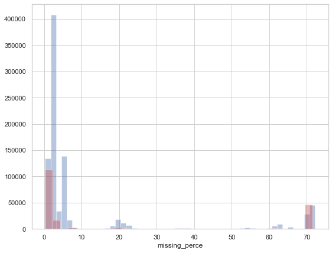

```python
plt.figure(figsize=(9,7))
sns.distplot(missing_prep_row_azdi.missing_perce , kde=False , color="b" ,label="Azdias" , )
sns.distplot(missing_prep_row_cust.missing_perce , kde=False , color="r",label="Customers")
```

##### conclusion

```python
befor_azur_shape = azdias.shape
print(f" before removing any rows Shape of global dataset {befor_azur_shape} ")
befor_cust_shape = customers.shape
print(f" before removing any rows Shape of global dataset {befor_cust_shape} ")
```

[output not shown]

```python
azdias = azdias.dropna(thresh= int(azdias.shape[1] * (1 - 0.2)))
customers = customers.dropna(thresh= int(customers.shape[1] * (1 - 0.2)))
```

```python
after_azur_shape = azdias.shape
print(f" After removing any rows Shape of global dataset {after_azur_shape}  removed rows {befor_azur_shape[0]-after_azur_shape[0]}")
after_cust_shape = customers.shape
print(f" After removing any rows Shape of global dataset {after_cust_shape} removed rows {befor_cust_shape[0]-after_cust_shape[0]}")
```

```
 After removing any rows Shape of global dataset (763864, 366)  removed rows 127357
 After removing any rows Shape of global dataset (138691, 369) removed rows 52961
```

##### Let's have a final look at dataframe infos

```python
azdias.info()
```

```
<class 'pandas.core.frame.DataFrame'>
Int64Index: 763864 entries, 1 to 891220
Columns: 366 entries, LNR to ALTERSKATEGORIE_GROB
dtypes: float64(275), int64(87), object(4)
memory usage: 2.1+ GB
```

```python
customers.info()
```

```
<class 'pandas.core.frame.DataFrame'>
Int64Index: 138691 entries, 0 to 191651
Columns: 369 entries, LNR to ALTERSKATEGORIE_GROB
dtypes: float64(275), int64(88), object(6)
memory usage: 391.5+ MB
```

```python
azdias_obj = azdias.select_dtypes("object")
azdias_obj.head()
```

|  | CAMEO_DEU_2015 | D19_LETZTER_KAUF_BRANCHE | EINGEFUEGT_AM | OST_WEST_KZ |
| --- | --- | --- | --- | --- |
| 1 | 8A | NaN | 1992-02-10 00:00:00 | W |
| 2 | 4C | D19_UNBEKANNT | 1992-02-12 00:00:00 | W |
| 3 | 2A | D19_UNBEKANNT | 1997-04-21 00:00:00 | W |
| 4 | 6B | D19_SCHUHE | 1992-02-12 00:00:00 | W |
| 5 | 8C | D19_ENERGIE | 1992-02-12 00:00:00 | W |

```python
customers_obj = customers.select_dtypes("object")
customers_obj.head()
```

|  | CAMEO_DEU_2015 | D19_LETZTER_KAUF_BRANCHE | EINGEFUEGT_AM | OST_WEST_KZ | PRODUCT_GROUP | CUSTOMER_GROUP |
| --- | --- | --- | --- | --- | --- | --- |
| 0 | 1A | D19_UNBEKANNT | 1992-02-12 00:00:00 | W | COSMETIC_AND_FOOD | MULTI_BUYER |
| 2 | 5D | D19_UNBEKANNT | 1992-02-10 00:00:00 | W | COSMETIC_AND_FOOD | MULTI_BUYER |
| 3 | 4C | D19_NAHRUNGSERGAENZUNG | 1992-02-10 00:00:00 | W | COSMETIC | MULTI_BUYER |
| 4 | 7B | D19_SCHUHE | 1992-02-12 00:00:00 | W | FOOD | MULTI_BUYER |
| 5 | 5D | D19_BUCH_CD | 1992-02-10 00:00:00 | W | COSMETIC_AND_FOOD | MULTI_BUYER |

```python
data_cat_lavels[data_cat_lavels.Attribute.isin(azdias_obj.columns)]
```

|  | Attribute | Description | Value | Meaning |
| --- | --- | --- | --- | --- |
| 61 | CAMEO_DEU_2015 | CAMEO classification 2015 - detailled classifi... | 1A | Work-Life-Balance |
| 62 | CAMEO_DEU_2015 | CAMEO classification 2015 - detailled classifi... | 1B | Wealthy Best Ager |
| 63 | CAMEO_DEU_2015 | CAMEO classification 2015 - detailled classifi... | 1C | Successful Songwriter |
| 64 | CAMEO_DEU_2015 | CAMEO classification 2015 - detailled classifi... | 1D | Old Nobility |
| 65 | CAMEO_DEU_2015 | CAMEO classification 2015 - detailled classifi... | 1E | City Nobility |
| 66 | CAMEO_DEU_2015 | CAMEO classification 2015 - detailled classifi... | 2A | Cottage Chic |
| 67 | CAMEO_DEU_2015 | CAMEO classification 2015 - detailled classifi... | 2B | Noble Jogger |
| 68 | CAMEO_DEU_2015 | CAMEO classification 2015 - detailled classifi... | 2C | Established gourmet |
| 69 | CAMEO_DEU_2015 | CAMEO classification 2015 - detailled classifi... | 2D | Fine Management |
| 70 | CAMEO_DEU_2015 | CAMEO classification 2015 - detailled classifi... | 3A | Career & Family |
| 71 | CAMEO_DEU_2015 | CAMEO classification 2015 - detailled classifi... | 3B | Powershopping Families |
| 72 | CAMEO_DEU_2015 | CAMEO classification 2015 - detailled classifi... | 3C | Rural Neighborhood |
| 73 | CAMEO_DEU_2015 | CAMEO classification 2015 - detailled classifi... | 3D | Secure Retirement |
| 74 | CAMEO_DEU_2015 | CAMEO classification 2015 - detailled classifi... | 4A | Family Starter |
| 75 | CAMEO_DEU_2015 | CAMEO classification 2015 - detailled classifi... | 4B | Family Life |
| 76 | CAMEO_DEU_2015 | CAMEO classification 2015 - detailled classifi... | 4C | String Trimmer |
| 77 | CAMEO_DEU_2015 | CAMEO classification 2015 - detailled classifi... | 4D | Empty Nest |
| 78 | CAMEO_DEU_2015 | CAMEO classification 2015 - detailled classifi... | 4E | Golden Ager |
| 79 | CAMEO_DEU_2015 | CAMEO classification 2015 - detailled classifi... | 5A | Younger Employees |
| 80 | CAMEO_DEU_2015 | CAMEO classification 2015 - detailled classifi... | 5B | Suddenly Family |
| 81 | CAMEO_DEU_2015 | CAMEO classification 2015 - detailled classifi... | 5C | Family First |
| 82 | CAMEO_DEU_2015 | CAMEO classification 2015 - detailled classifi... | 5D | Stock Market Junkies |
| 83 | CAMEO_DEU_2015 | CAMEO classification 2015 - detailled classifi... | 5E | Coffee Rider |
| 84 | CAMEO_DEU_2015 | CAMEO classification 2015 - detailled classifi... | 5F | Active Retirement |
| 85 | CAMEO_DEU_2015 | CAMEO classification 2015 - detailled classifi... | 6A | Jobstarter |
| 86 | CAMEO_DEU_2015 | CAMEO classification 2015 - detailled classifi... | 6B | Petty Bourgeois |
| 87 | CAMEO_DEU_2015 | CAMEO classification 2015 - detailled classifi... | 6C | Long-established |
| 88 | CAMEO_DEU_2015 | CAMEO classification 2015 - detailled classifi... | 6D | Sportgardener |
| 89 | CAMEO_DEU_2015 | CAMEO classification 2015 - detailled classifi... | 6E | Urban Parents |
| 90 | CAMEO_DEU_2015 | CAMEO classification 2015 - detailled classifi... | 6F | Frugal Aging |
| 91 | CAMEO_DEU_2015 | CAMEO classification 2015 - detailled classifi... | 7A | Journeymen |
| 92 | CAMEO_DEU_2015 | CAMEO classification 2015 - detailled classifi... | 7B | Mantaplatte |
| 93 | CAMEO_DEU_2015 | CAMEO classification 2015 - detailled classifi... | 7C | Factory Worker |
| 94 | CAMEO_DEU_2015 | CAMEO classification 2015 - detailled classifi... | 7D | Rear Window |
| 95 | CAMEO_DEU_2015 | CAMEO classification 2015 - detailled classifi... | 7E | Interested Retirees |
| 96 | CAMEO_DEU_2015 | CAMEO classification 2015 - detailled classifi... | 8A | Multi-culteral |
| 97 | CAMEO_DEU_2015 | CAMEO classification 2015 - detailled classifi... | 8B | Young & Mobile |
| 98 | CAMEO_DEU_2015 | CAMEO classification 2015 - detailled classifi... | 8C | Prefab |
| 99 | CAMEO_DEU_2015 | CAMEO classification 2015 - detailled classifi... | 8D | Town Seniors |
| 100 | CAMEO_DEU_2015 | CAMEO classification 2015 - detailled classifi... | 9A | First Shared Apartment |
| 101 | CAMEO_DEU_2015 | CAMEO classification 2015 - detailled classifi... | 9B | Temporary Workers |
| 102 | CAMEO_DEU_2015 | CAMEO classification 2015 - detailled classifi... | 9C | Afternoon Talk Show |
| 103 | CAMEO_DEU_2015 | CAMEO classification 2015 - detailled classifi... | 9D | Mini-Jobber |
| 104 | CAMEO_DEU_2015 | CAMEO classification 2015 - detailled classifi... | 9E | Socking Away |
| 2013 | OST_WEST_KZ | flag indicating the former GDR/FRG | -1 | unknown |
| 2014 | OST_WEST_KZ | flag indicating the former GDR/FRG | O | East (GDR) |
| 2015 | OST_WEST_KZ | flag indicating the former GDR/FRG | W | West (FRG) |

```python
azdias.CAMEO_DEU_2015.value_counts()
```

```
6B    55151
8A    51381
4C    45874
2D    34046
3C    33719
7A    33432
3D    33218
8B    32098
4A    31715
8C    30476
9D    27465
9B    26529
9C    23784
7B    23609
9A    20238
2C    18613
8D    17118
6E    15822
2B    14801
5D    14406
6C    14274
2A    12698
1D    11709
5A    10622
1A    10519
5B    10025
5C     9477
4B     8674
7C     8506
4D     8317
3A     8082
6A     6569
3B     6522
6D     5892
6F     5205
4E     5163
1E     4920
9E     4901
7D     4774
7E     4477
1C     4149
5F     4108
1B     3943
5E     3403
XX      297
Name: CAMEO_DEU_2015, dtype: int64
```

##### here are the labels

1A Work-Life-Balance 1B Wealthy Best Ager 1C Successful Songwriter 1D Old Nobility 1E City Nobility 2A Cottage Chic 2B Noble Jogger 2C Established gourmet 2D Fine Management 3A Career & Family 3B Powershopping Families 3C Rural Neighborhood 3D Secure Retirement 4A Family Starter 4B Family Life 4C String Trimmer 4D Empty Nest 4E Golden Ager 5A Younger Employees 5B Suddenly Family 5C Family First 5D Stock Market Junkies 5E Coffee Rider 5F Active Retirement 6A Jobstarter 6B Petty Bourgeois 6C Long-established 6D Sportgardener 6E Urban Parents 6F Frugal Aging 7A Journeymen 7B Mantaplatte 7C Factory Worker 7D Rear Window 7E Interested Retirees 8A Multi-culteral 8B Young & Mobile 8C Prefab 8D Town Seniors 9A First Shared Apartment 9B Temporary Workers 9C Afternoon Talk Show 9D Mini-Jobber 9E Socking Away

```python
azdias.D19_LETZTER_KAUF_BRANCHE.value_counts()
```

```
D19_UNBEKANNT             185338
D19_VERSICHERUNGEN         54603
D19_SONSTIGE               42291
D19_VOLLSORTIMENT          32849
D19_SCHUHE                 30359
D19_BUCH_CD                27184
D19_VERSAND_REST           24548
D19_DROGERIEARTIKEL        22604
D19_BANKEN_DIREKT          21974
D19_BEKLEIDUNG_REST        20305
D19_HAUS_DEKO              19729
D19_TELKO_MOBILE           13670
D19_ENERGIE                11534
D19_TELKO_REST             10882
D19_BANKEN_GROSS            9933
D19_BEKLEIDUNG_GEH          9640
D19_FREIZEIT                6776
D19_KINDERARTIKEL           6764
D19_TECHNIK                 6580
D19_LEBENSMITTEL            6078
D19_BANKEN_REST             4937
D19_RATGEBER                4675
D19_NAHRUNGSERGAENZUNG      3876
D19_DIGIT_SERV              3399
D19_REISEN                  2932
D19_TIERARTIKEL             2424
D19_SAMMELARTIKEL           2307
D19_HANDWERK                2107
D19_WEIN_FEINKOST           2048
D19_GARTEN                  1546
D19_BANKEN_LOKAL            1364
D19_BIO_OEKO                1149
D19_BILDUNG                  922
D19_LOTTO                    771
D19_KOSMETIK                 745
Name: D19_LETZTER_KAUF_BRANCHE, dtype: int64
```

```python
azdias.OST_WEST_KZ.value_counts()
```

```
W    602335
O    161529
Name: OST_WEST_KZ, dtype: int64
```

Let's have a look at above 4 common columns = ['CAMEO_DEU_2015', 'D19_LETZTER_KAUF_BRANCHE', 'EINGEFUEGT_AM', 'OST_WEST_KZ']

1. "EINGEFUEGT_AM" :- we can convert it into date time feature
2. "CAMEO_DEU_2015" :- It has information of very detailed classification ,we can convert it into the dummies but , it will increase more features again so it is not useful. we can remove it.
3. "D19_LETZTER_KAUF_BRANCHE" :- didn't found any information and also a multi level column so we can remove it
4. "OST_WEST_KZ" :- we can convert it into dummies or labels